# IODS final project

Sampsa Huttunen

March 8, 2017

## Abstract

This final assignment analyzes the relation between extra-marital affairs (i.e. adultery or “cheating”) with some other variables related to personal and marital life in the United States at the end of the 1960’s and in the beginning of 1970s. According to my results, the factor correlating most with the likelihood to have an extra-marital affair seems to be (maybe unsurprisingly) one’s happiness in his/her marriage.

## 1 Research Question

This assignment uses a dataset originally used in Ray C. Fair’s 1977 (Fair 1977) study of extra-marital affairs to see what factors correlated with a tendency to cheat on one’s spouse in the United States in the 1960s and 1970s.

My hypothesis is that, while other factors may also play a role, not being happy in one’s marriage is the strongest factor increasing the likelihood for an extra-marital relationship.

The statistical method applied in this assignment will be linear regression. It will be used to study the correlation between the number of an individual’s extra-marital affairs (‘nbaffairs’, dependant variable) and other variables present in the data (independent variables).

## 2 Data

The dataset discussed here is a data of 601 answers of individuals to sex-related questions. It is a sample of a two surveys conducted in the United States: A survey by Psychology Today in 1969 and a survey by Redbook in 1974. Only employed people and people who were married and married for the first time were included in this dataset.

### 2.1 The Variables

##### The dataset contains the following variables:

- sex - sex (male,female)
- age - age
- ym - number of years married
- child - children (no/yes)
- religious - how religious from 1 (anti) to 5 (very)
- education - education:
  - 9.0 - Grade school
  - 12.0 - High school
  - 14.0 - Some college
  - 16.0 - College graduate
  - 17.0 - Some graduate school
  - 18.0 - Master’s degree
  - 20.0 - Ph.D., M.D., or other advanced degree.
- occupation - occupation, according to Hollingshead Index of Social Positions (ISP) Occupational Scale (with reversed numbering):
  - 7 - Higher executives of large concerns, proprietors, and major professionals
  - 6 - Business managers, proprietors of medium-sized businesses, and lesser professionals
  - 5 - Administrative personnel, owners of small businesses, and minor professionals
  - 4 - Clerical and sales workers, technicians, and owners of little businesses
  - 3 - Skilled manual employees
  - 2 - Machine operators and semiskilled employees
  - 1 - Unskilled employees.
- rate - self rating of marriage from 1 (very unhappy) to 5 (very happy)
- nbaffairs - number of affairs in the past year:
  - 0 - none
  - 1 - once
  - 2 - twice
  - 3 - 3 times
  - 7 - 4 to 10 times
  - 12 - monthly or more

### 2.2 Data Wrangling

The original dataset ‘Fair.csv’ had an extra column with row index numbers. That column was omitted.

The separator between values was also changed to “;” to make the CSV data comply and open neatly with the European Excel versions. The wrangled dataset was then written to a file ‘affairs.csv’ to be used in the analysis.

### 2.3 The Files

The original dataset (Fair.csv) was downloaded from https://vincentarelbundock.github.io/Rdatasets/csv/Ecdat/Fair.csv  
The R script used to create the new dataset is at https://github.com/huttusam/IODS-final/blob/master/final-assignment.R  
and the ‘affairs’ dataset used in this assignment is at https://github.com/huttusam/IODS-final/blob/master/data/affairs.csv

## 3 Analysis, Results, and Conclusions

```r
# Access libraries
library(dplyr)
library(ggplot2)
library(GGally)
library(stringr)
library(tidyverse)

# reading data from the wrangled CSV file to table 'affairs'
affairs <- read.table("data/affairs.csv", sep = ";", header = TRUE)

# printing a summary of affairs
summary(affairs)
```

```
##      sex           age              ym         child       religious
##  female:315   Min.   :17.50   Min.   : 0.125   no :171   Min.   :1.000
##  male  :286   1st Qu.:27.00   1st Qu.: 4.000   yes:430   1st Qu.:2.000
##               Median :32.00   Median : 7.000             Median :3.000
##               Mean   :32.49   Mean   : 8.178             Mean   :3.116
##               3rd Qu.:37.00   3rd Qu.:15.000             3rd Qu.:4.000
##               Max.   :57.00   Max.   :15.000             Max.   :5.000
##    education       occupation         rate         nbaffairs
##  Min.   : 9.00   Min.   :1.000   Min.   :1.000   Min.   : 0.000
##  1st Qu.:14.00   1st Qu.:3.000   1st Qu.:3.000   1st Qu.: 0.000
##  Median :16.00   Median :5.000   Median :4.000   Median : 0.000
##  Mean   :16.17   Mean   :4.195   Mean   :3.932   Mean   : 1.456
##  3rd Qu.:18.00   3rd Qu.:6.000   3rd Qu.:5.000   3rd Qu.: 0.000
##  Max.   :20.00   Max.   :7.000   Max.   :5.000   Max.   :12.000
```

```r
# n= 601; 315 females, 286 males; mean age: 32.48 years
```

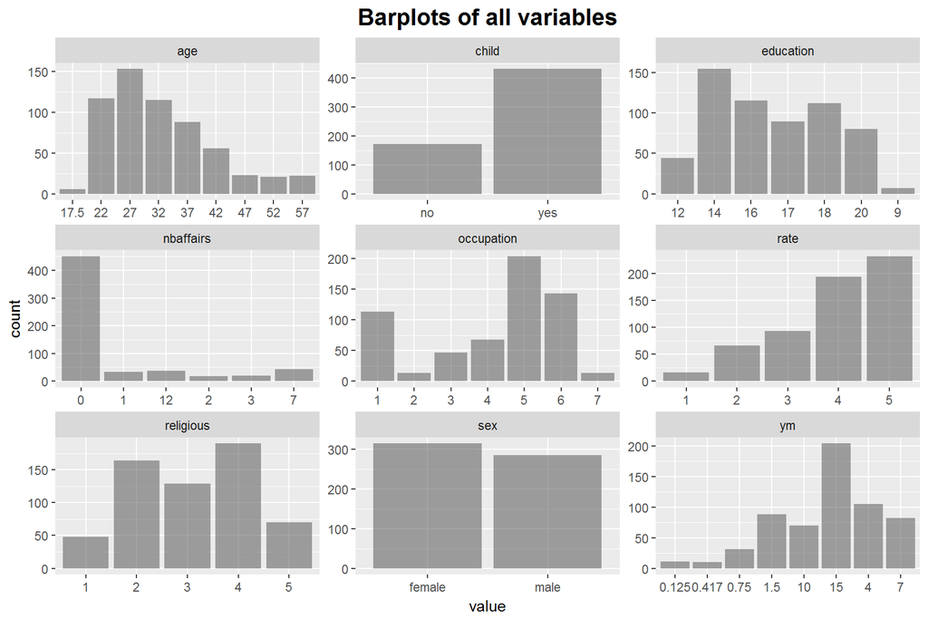

```r
# printing a graphical summarization of affairs
gather(affairs) %>% ggplot(aes(value, alpha=0.3)) + facet_wrap("key", scales = "free") + geom_bar() + ggtitle("Barplots of all variables") +
  theme(plot.title = element_text(hjust = 0.5,size=16,face='bold'),legend.position="none")
```

When we look at the bar visualization of the data above, we can see that most participants have had at least some years of college education, are in administrative or managerial positions, are happy with their marriage, are somewhat religious, and have not had any extra-marital relationships.  
Who, then, has these relationships?

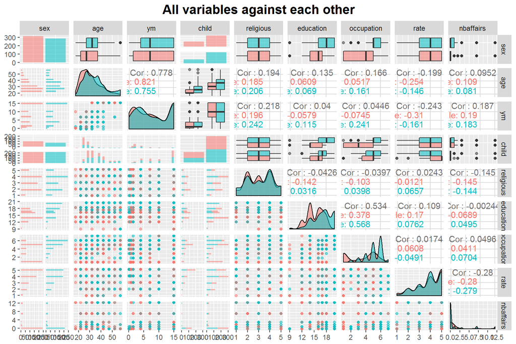

```r
p <- ggpairs(affairs, mapping = aes(col = sex, alpha = 0.3), lower = list(combo = wrap("facethist", bins = 20))) + ggtitle("All variables against each other") + theme(plot.title = element_text(hjust = 0.5,size=16,face='bold'))
p
```

The above summary shows that women (in red) and men (in blue) don’t differ very much in the number of extra-marital relations (see the lower right corner of the graph). The summary also indicates some interesting correlations with extra-marital affairs. There is a negative correlation between cheating and how people rate their marriage (-0.28), some correlation between cheating and years in marriage (0.187), as well as a slight negative correlation between cheating and religiousness (-0.145). Let’s look at these pairs more closely:

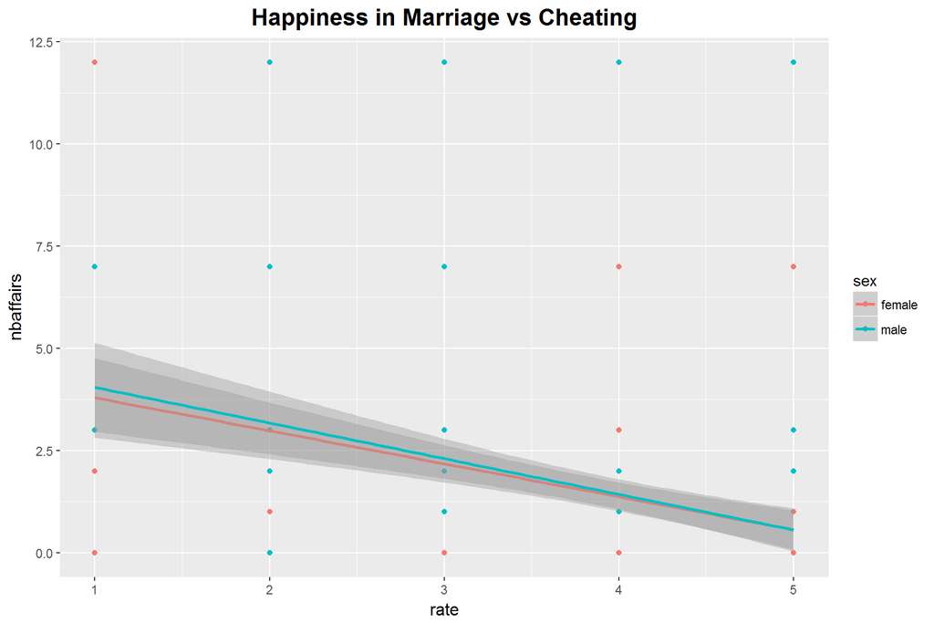

```r
# Plotting nbaffairs vs rate
p1 <- ggplot(affairs, aes(x = rate, y = nbaffairs, col=sex)) +
  geom_point() + geom_smooth(method="lm") +
  ggtitle("Happiness in Marriage vs Cheating")+
  theme(plot.title = element_text(hjust = 0.5,size=16,face='bold'),
        axis.title= element_text(hjust = 0.5,size=12))
p1
```

```r
# fit a linear model
my_model1 <- lm(nbaffairs ~ rate, data = affairs)

# print out a summary of the model
summary(my_model1)
```

```
##
## Call:
## lm(formula = nbaffairs ~ rate, data = affairs)
##
## Residuals:
##     Min      1Q  Median      3Q     Max
## -3.9063 -1.3989 -0.5631 -0.5631 11.4369
##
## Coefficients:
##             Estimate Std. Error t value Pr(>|t|)
## (Intercept)   4.7421     0.4790   9.900   <2e-16 ***
## rate         -0.8358     0.1173  -7.125    3e-12 ***
## ---
## Signif. codes:  0 '***' 0.001 '**' 0.01 '*' 0.05 '.' 0.1 ' ' 1
##
## Residual standard error: 3.17 on 599 degrees of freedom
## Multiple R-squared:  0.07813,    Adjusted R-squared:  0.07659
## F-statistic: 50.76 on 1 and 599 DF,  p-value: 3.002e-12
```

As we can see from the above linear regression plot, there is a clear negative correlation between the number of extra-marital affairs and the self-rated happiness of one’s marriage. Although the data shows only a correlation between these two factors, the causality behind this correlation might run from experienced unhappiness to cheating. While this explanation feels plausible, further study is needed to confirm the direction of the causality.

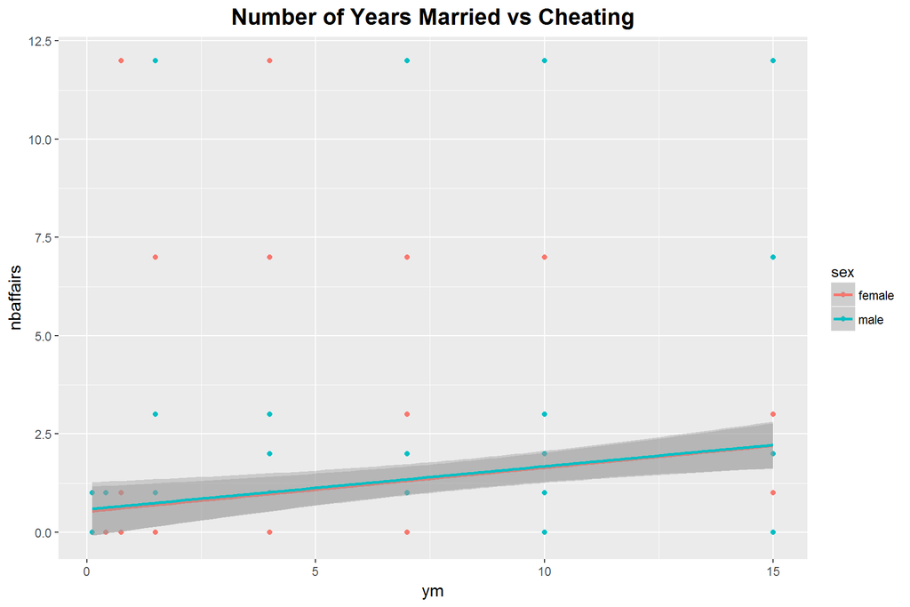

```r
# Plotting nbaffairs vs ym
p2 <-ggplot(affairs, aes(x = ym, y = nbaffairs, col=sex)) +
  geom_point() + geom_smooth(method="lm") +
  ggtitle("Number of Years Married vs Cheating")+
  theme(plot.title = element_text(hjust = 0.5,size=16,face='bold'),
        axis.title= element_text(hjust = 0.5,size=12))
p2
```

```r
# fit a linear model
my_model2 <- lm(nbaffairs ~ ym, data = affairs)

# print out a summary of the model
summary(my_model2)
```

```
##
## Call:
## lm(formula = nbaffairs ~ ym, data = affairs)
##
## Residuals:
##     Min      1Q  Median      3Q     Max
## -2.2106 -1.6575 -0.9937 -0.5974 11.3658
##
## Coefficients:
##             Estimate Std. Error t value Pr(>|t|)
## (Intercept)  0.55122    0.23511   2.345   0.0194 *
## ym           0.11063    0.02377   4.655    4e-06 ***
## ---
## Signif. codes:  0 '***' 0.001 '**' 0.01 '*' 0.05 '.' 0.1 ' ' 1
##
## Residual standard error: 3.243 on 599 degrees of freedom
## Multiple R-squared:  0.03491,    Adjusted R-squared:  0.0333
## F-statistic: 21.67 on 1 and 599 DF,  p-value: 3.996e-06
```

The number of years in marriage also seems to contribute to the likelihood of extra-marital relations. The bitter truth behind this might be that, over time, people get bored of their spouses and begin to seek some additional excitement to their (sex) life.

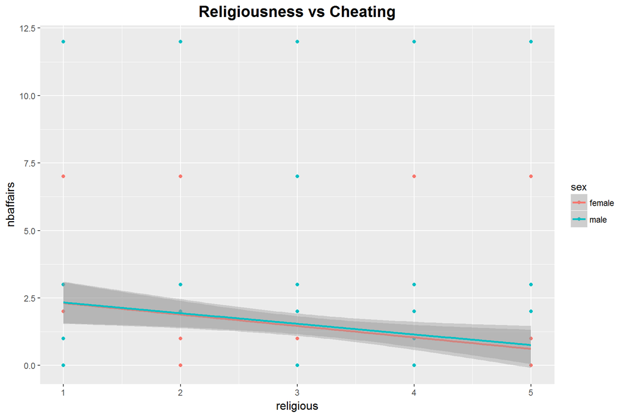

```r
# Plotting nbaffairs vs religious
p3 <-ggplot(affairs, aes(x = religious, y = nbaffairs, col=sex)) +
  geom_point() + geom_smooth(method="lm") +
  ggtitle("Religiousness vs Cheating") +
  theme(plot.title = element_text(hjust = 0.5,size=16,face='bold'),
        axis.title= element_text(hjust = 0.5,size=12))
p3
```

```r
# fit a linear model
my_model3 <- lm(nbaffairs ~ religious, data = affairs)

# print out a summary of the model
summary(my_model3)
```

```
##
## Call:
## lm(formula = nbaffairs ~ religious, data = affairs)
##
## Residuals:
##     Min      1Q  Median      3Q     Max
## -2.3200 -1.9117 -1.0952 -0.6869 11.3131
##
## Coefficients:
##             Estimate Std. Error t value Pr(>|t|)
## (Intercept)   2.7283     0.3801   7.177 2.11e-12 ***
## religious    -0.4083     0.1142  -3.574  0.00038 ***
## ---
## Signif. codes:  0 '***' 0.001 '**' 0.01 '*' 0.05 '.' 0.1 ' ' 1
##
## Residual standard error: 3.267 on 599 degrees of freedom
## Multiple R-squared:  0.02088,    Adjusted R-squared:  0.01925
## F-statistic: 12.77 on 1 and 599 DF,  p-value: 0.0003797
```

Religiousness, on the other hand, seems to decrease the likelihood of extra-marital affairs. The type of the religion, the participant was affiliated with, was not in the data, but most of the world’s religions condemn adultery. This, in turn, might decrease a religious person’s willingness to have extra-marital affairs.

## 4 Discussion

Since the dataset used in this assignment was somewhat small and the data obtained a long time ago and in an unorthodox way, the results and conlcusions drawn from it can only be tentative. Further study is needed to address more closely and accurately the phenomenon of extra-marital affairs and the individual and societal reasons behind it.

## References

Fair, R. (1977) “A note on the computation of the tobit estimator”, Econometrica, 45, 1723-1727. http://fairmodel.econ.yale.edu/rayfair/pdf/1978A200.PDF